# Competition for pollen deposition space on pollinators generates an advantage for the last male visited

# Data

Data description and summary statitiscs. From the 43 pairwise presentations, we did not found any pollen in 12, neither for C or T.

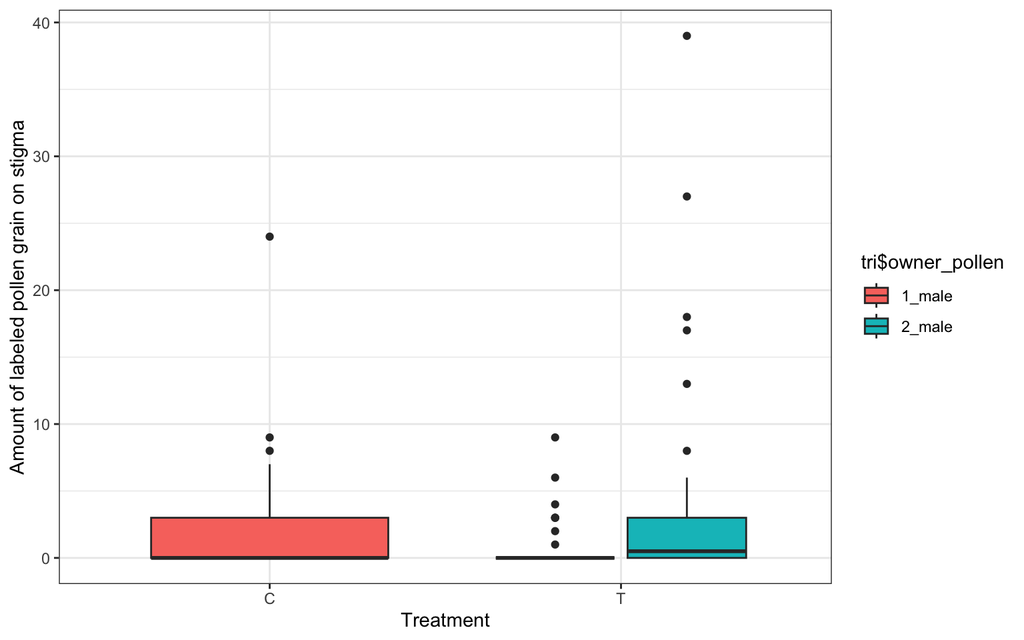

# Modeling the probability of a male to achieve the stigma

The probability (achieved or not) is modeled by male position (first or second) and the treatment (control or trials), and as random effect the bird id.

Mixed effects model, including bird identity as random intercept.

Binomial distribution

```r
m <- glmmTMB(presence_ausence ~ treatment*owner_pollen + (1|bird_id),
              family=binomial, data= tri)
#dropping columns from rank-deficient conditional model: treatmentT:owner_pollen2_male

m0 <- glmmTMB(presence_ausence ~ treat + (1|bird_id/exp_trial),
              family=binomial, data= tri)
m1 <- glmmTMB(presence_ausence ~ treat + (1|bird_id),
              family=binomial, data= tri)
m2<-glmmTMB(presence_ausence ~ treatment + (1|bird_id),
              family=binomial, data= tri)
m3<-glmmTMB(presence_ausence ~ 1 + (1|bird_id),
              family=binomial, data= tri)

kable(bbmle::AICtab(m0,m1,m2,m3, base=T, weights=T), digits=2)
```

|  | AIC | dAIC | df | weight |
| --- | --- | --- | --- | --- |
| m1 | 166.52 | 0.00 | 4 | 0.66 |
| m0 | 167.98 | 1.45 | 5 | 0.32 |
| m3 | 174.90 | 8.37 | 2 | 0.01 |
| m2 | 175.29 | 8.77 | 3 | 0.01 |

The model m0 and m1 are equaly plausible.

## Residual diagnostic of the selected models

Using the `DHARMa` package.

The two most plausible models presented a satisfactory residual diagnostic.

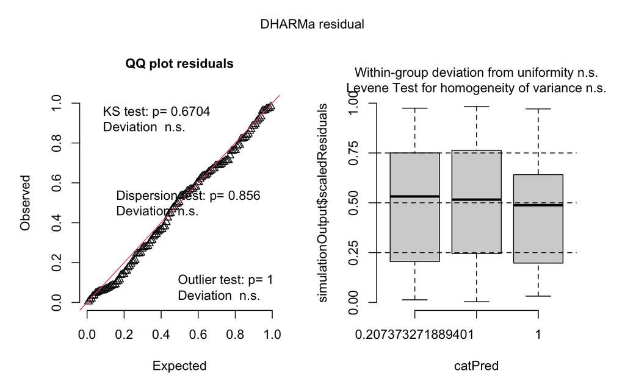

```r
plot(simulateResiduals(m0))
```

```r
#plot(simulateResiduals(m1))
```

## Models results

Predicting the probability of reaching a stigma.

```
##  Family: binomial  ( logit )
## Formula:          presence_ausence ~ treat + (1 | bird_id/exp_trial)
## Data: tri
##
##      AIC      BIC   logLik deviance df.resid
##    168.0    182.3    -79.0    158.0      125
##
## Random effects:
##
## Conditional model:
##  Groups            Name        Variance Std.Dev.
##  exp_trial:bird_id (Intercept) 0.3620   0.6017
##  bird_id           (Intercept) 0.3032   0.5506
## Number of obs: 130, groups:  exp_trial:bird_id, 43; bird_id, 8
##
## Conditional model:
##               Estimate Std. Error z value Pr(>|z|)
## (Intercept)    -0.2259     0.4009  -0.564  0.57312
## treatT_1_male  -1.4804     0.5496  -2.694  0.00707 **
## treatT_2_male   0.2203     0.4678   0.471  0.63773
## ---
## Signif. codes:  0 '***' 0.001 '**' 0.01 '*' 0.05 '.' 0.1 ' ' 1
```

```
## # R2 for Mixed Models
##
##   Conditional R2: 0.275
##      Marginal R2: 0.128
```

| treat.x | treat.predicted | treat.std.error | treat.conf.low | treat.conf.high | treat.group |
| --- | --- | --- | --- | --- | --- |
| T_1_male | 0.15 | 0.50 | 0.06 | 0.33 | treat |
| T_2_male | 0.50 | 0.39 | 0.32 | 0.68 | treat |
| C_1_male | 0.44 | 0.40 | 0.27 | 0.64 | treat |

[figure not shown]

# Exploring the amount of pollen grains that arrive on the stigma

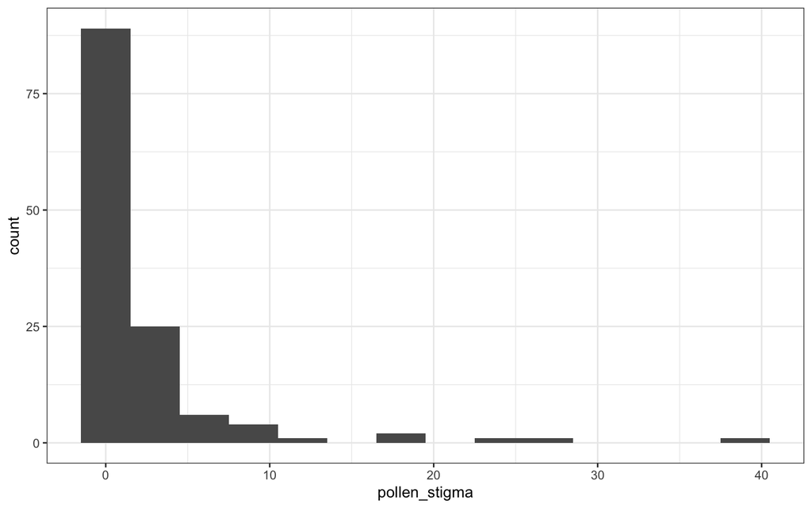

Our data is zero inflated, indicating that we should compare zero inflated models, negative binomial and other hurdle models.

Zero inflated models are only a possibility if in some cases, the only answer possible is zero. In our case, if no pollen is deposited on pollinator body, no pollen will be deposited on stigma.

On the other option, hurdle models are zero truncated, it means that we are modelling only the pollen distribution of pollen deposited on stigma and we are saying that is a different process: if some pollen is deposited, zero is out of the possibilities.

# Modeling the amount of pollen grains achieve the stigma

```r
c0<-glm(tri$pollen_stigma~tri$treatment*tri$owner_pollen, family=poisson)
c1 <- glm.nb(pollen_stigma ~ treat, data=tri)
#c2<-glmer.nb(pollen_stigma ~ treat+(1|bird_id/exp_trial), data=tri)#singularity
c2<-glmmTMB(pollen_stigma ~ treat+(1|exp_trial), data=tri, family=nbinom2)
# Hurdle or truncated Poisson model coefficients
c3 <- hurdle(pollen_stigma ~ treat | treat, link = "logit", dist = "poisson", data=tri)
# Hurdle or truncated negative binonomial model coefficients
c4 <- hurdle(pollen_stigma ~ treat | treat, link = "logit", dist = "negbin", data=tri)
# Zero-inflated Poisson model coefficients
c5 <- zeroinfl(pollen_stigma ~ treat | treat, link = "logit", dist = "poisson", data=tri)
# Zero-inflated negative binomial model coefficients
c6 <- zeroinfl(pollen_stigma ~ treat | treat, link = "logit", dist = "negbin", data=tri)
c7<- glmmTMB(pollen_stigma ~ 1+(1|exp_trial), data=tri, family=nbinom2)
c8<- glmmTMB(pollen_stigma ~ 1, data=tri, family=nbinom2)

bbmle::AICtab(c0,c1,c2, c3, c4,c5,c6,c7,c8, base=T,
       weights=T) %>%
  kable(digits=2)
```

|  | AIC | dAIC | df | weight |
| --- | --- | --- | --- | --- |
| c2 | 427.57 | 0.00 | 5 | 0.39 |
| c1 | 428.40 | 0.83 | 4 | 0.26 |
| c4 | 429.26 | 1.68 | 7 | 0.17 |
| c6 | 429.26 | 1.68 | 7 | 0.17 |
| c8 | 434.52 | 6.95 | 2 | 0.01 |
| c7 | 434.58 | 7.00 | 3 | 0.01 |
| c3 | 606.94 | 179.37 | 6 | 0.00 |
| c5 | 606.94 | 179.37 | 6 | 0.00 |
| c0 | 915.36 | 487.79 | 3 | 0.00 |

## Models result

We found four equally plausible models (delta AIC menor que 2) for the pollen counted on the stigma. The best fitted model was the model with describe the data with a negative binomial distribution and sequence affected the amount of pollen on stigma, having the trial as a random intercept. The second equally plausible model did not have the random factor, the third was using a hurdle model and the last one using a zero inflated model.

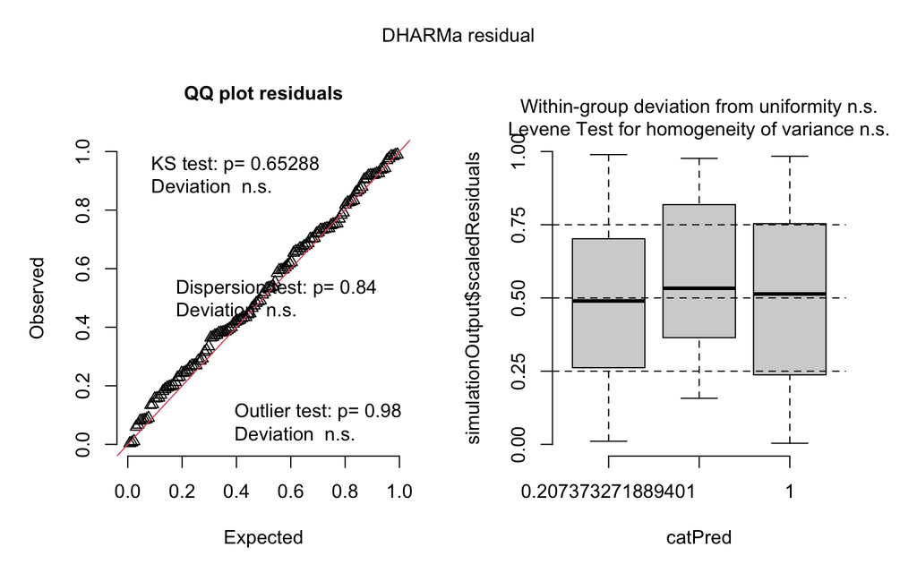

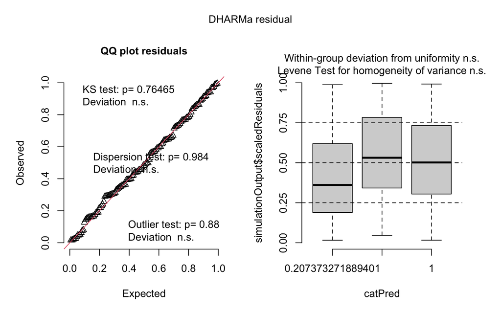

```
## Zero-inflated negative binomial model
```

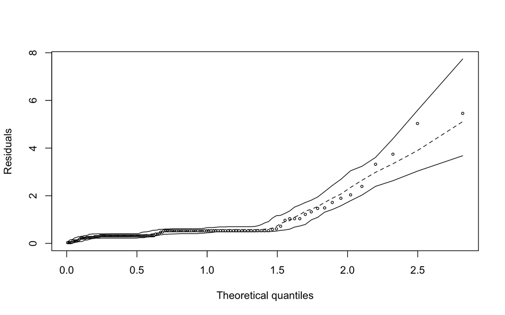

```
## Hurdle negative binomial model
```

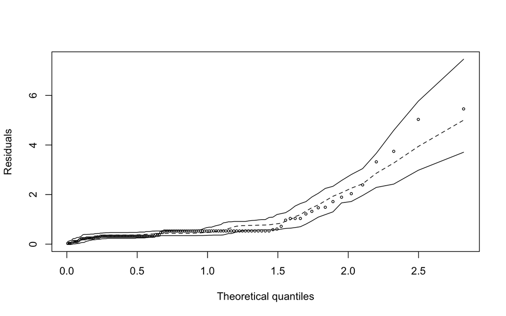

The most plausible models presented a satisfactory residual diagnostic.

```
## # R2 for Mixed Models
##
##   Conditional R2: 0.453
##      Marginal R2: 0.195
```

| treat.x | treat.predicted | treat.std.error | treat.conf.low | treat.conf.high | treat.group |
| --- | --- | --- | --- | --- | --- |
| T_1_male | 0.45 | 0.47 | 0.18 | 1.15 | treat |
| T_2_male | 2.55 | 0.38 | 1.21 | 5.36 | treat |
| C_1_male | 1.74 | 0.38 | 0.83 | 3.64 | treat |

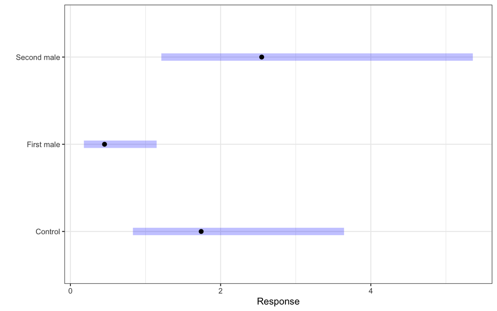

[output not shown]

```
## [1] "C_1_male" "T_1_male" "T_2_male"
```

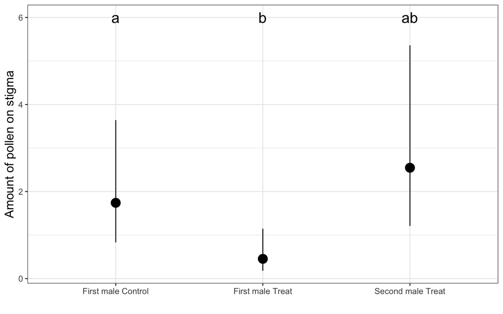